# Resumen Análisis

# Pasos

1. Acceder a los datos

2. Revisar la estructura de datos

3. Transformar variable

4. Estadística descriptiva de variables

5. Representación gráfica de variables

6. Análisis de distribución

# Acceder a los datos

Hasta el momento hemos accedido a los datos dentro del paquete `NeurocienciasIntroData`.
Esto nos ahorra el problema de leer los datos de una fuente de datos externa.
Sin embargo la mayoría de las veces que se obtienen datos es de archivos externos:

- **CSV** valores separados por comas (`read.csv`, `read_csv`<sup>1</sup>, `fread`<sup>2</sup>)
- **Excel** necesita la librería `readxl()` aunque hay otra alternativa.
- **Google Sheets** usa la librería `googlesheets4()` al ser un servicio en la nube
permite interacción de varios usuarios y acceso en línea.

> Existen otros archivos como los **SPSS**, **Stata**  o **Sas** entre otros
para archivos distintos existen paquetes específicos. Como `foreign()`

[1] Del paquete `readr()`.

[2] Del paquete `data.table()`

# Estructura de datos

Existen varios comandos para determinar la estructura de un objeto, sin embargo
el comando `str()` de _r-base_ permite inspeccionar la estructura de cualquier objeto.

Por ejemplo podemos revisar la estructura del dataset integrado a **R**

```r
str(cars)
```

```
## 'data.frame':	50 obs. of  2 variables:
##  $ speed: num  4 4 7 7 8 9 10 10 10 11 ...
##  $ dist : num  2 10 4 22 16 10 18 26 34 17 ...
```

Este comando nos muestra el tipo de columna y las dimensiones del mismo.

# Transformar variables

Para procesar adecuadamente los datos es necesario considerar el tipo de variable
y codificarlas como tal.

En general transformar los datos a números es un proceso directo con las funciones
`as.numeric()`<sup>3</sup>, `as.double()`<sup>4</sup> `as.integer()`<sup>5</sup>

Para los datos lógicos se puede convertir 0 y 1 a FALSO y VERDADERO con `as.logical()`

Los valores nominales únicos pueden mantenerse como texto o convertirse a `as.chararcter()`

Los **factores** son quiza el tipo de variable con una utilidad directa.

[3] Números con decimales

[4] Números con decimales de doble precisión.

[5] Números enteros.

# Factores

Los factores se pueden definir de dos formas, con la función `as.factor()` que
convertirá un vector a factor asumiendo las características de orden, etiquetas y
niveles.

```r
set.seed(12)
vector.letras <- sample(letters[1:3], 20, replace = TRUE)
factores.default <- as.factor(vector.letras)
factores.default
```

```
##  [1] b b c c b a a b c b a b a b b b c a a c
## Levels: a b c
```

# Factores

También se puede mediante la función `factor()` donde se puede definir cada
característica del factor, orden, etiquetas y niveles extra

```r
factores.manual <- factor(
  vector.letras,
  levels = c("c", "b", "a", "d"),
  labels = c("C", "B", "A", "D"),
  ordered = TRUE
)
factores.manual
```

```
##  [1] B B C C B A A B C B A B A B B B C A A C
## Levels: C < B < A < D
```

# Estadística descriptiva

Con las variables bien codificadaspodemos aplicar estadísticas descriptivas:

### Media de una variable

```r
mean(mtcars$mpg)
```

```
## [1] 20.09062
```

### Desviación estandar

```r
sd(mtcars$mpg)
```

```
## [1] 6.026948
```

# Estadística descriptiva

Si las variables que analizamos están bien definidas podemos usar comandos como
`summary()` para tener métricas estadísticas generadas en automático.

```r
summary(iris[, c("Species", "Sepal.Length", "Petal.Length")])
```

```
##        Species    Sepal.Length    Petal.Length
##  setosa    :50   Min.   :4.300   Min.   :1.000
##  versicolor:50   1st Qu.:5.100   1st Qu.:1.600
##  virginica :50   Median :5.800   Median :4.350
##                  Mean   :5.843   Mean   :3.758
##                  3rd Qu.:6.400   3rd Qu.:5.100
##                  Max.   :7.900   Max.   :6.900
```

## Representación gráfica de variables

### Boxplot

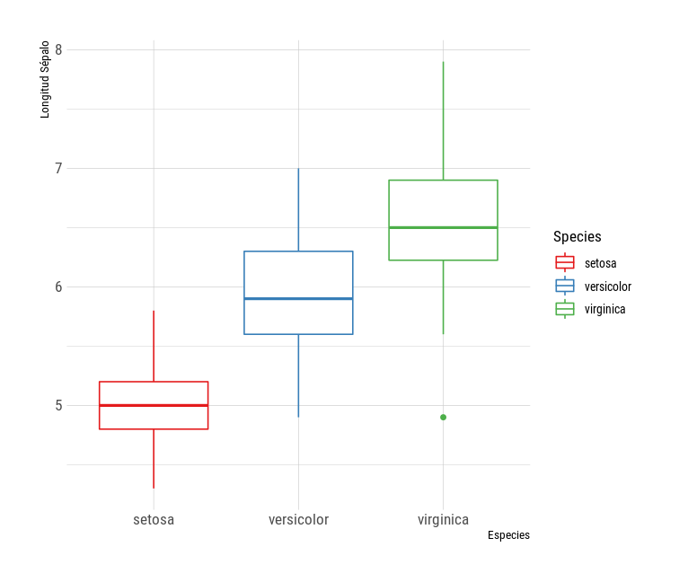

```r
ggplot(iris) +
  geom_boxplot(aes(
    x = Species,
    y = Sepal.Length,
    color = Species
  )) +
  scale_color_brewer(palette = "Set1") +
  theme_ipsum_rc() +
  labs(
    x = "Especies",
    y = "Longitud Sépalo"
  )
```

## Representación gráfica de variables

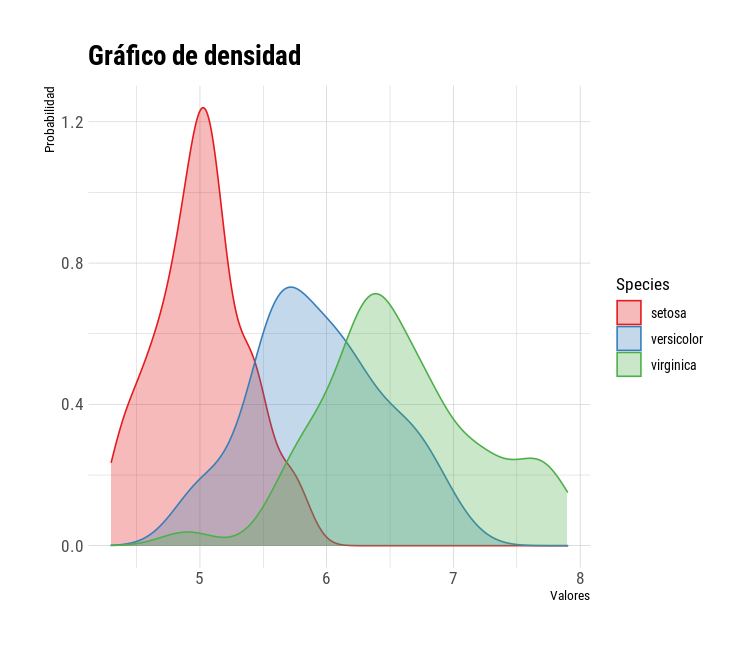

```r
ggplot(iris) +
  geom_density(
    aes(x = Sepal.Length,
        fill = Species,
        color = Species
    ),
    alpha = 0.3
  ) +
  scale_fill_brewer(palette = "Set1") +
  scale_color_brewer(palette = "Set1") +
  theme_ipsum_rc() +
  labs(
    x = "Valores",
    y = "Probabilidad",
    title = "Gráfico de densidad"
  )
```

# Análisis de distribución

Podemos probar el tipo de distribución con con técnicas estadísticas y gráficas.

- Shapiro-Wilk

- Kolmogorov-Smirnov

- qqplot

# Análisis de distribución

### Shapiro-Wilk

* **Hipótesis nula** = datos tienen una distribución normal
  * **Hipótesis alterna** = datos **NO** tieen distribución normal
  * **p-value < 0.05** = se rechaza hipótesis nula

```r
shapiro.test(iris$Sepal.Length)
```

```
##
## 	Shapiro-Wilk normality test
##
## data:  iris$Sepal.Length
## W = 0.97609, p-value = 0.01018
```

> En esta caso el resultado de p = 0.01018 y como 0.0108 es **menor** a 0.05
se **rechaza** la hipótesis nula o sea **la distribución no es normal**.

# Análisis de distribución

### Kolmogorov-Smirnov<sup>6</sup>

* **Hipótesis nula** = datos tienen una distribución normal
  * **Hipótesis alterna** = datos **NO** tienen distribución normal
  * **p-value < 0.05** = se rechaza hipótesis nula

```r
media_sepalength <- mean(iris$Sepal.Length)
sd_sepalength <- sd(iris$Sepal.Length)
ks.test(
  iris$Sepal.Length,
  "pnorm",
  media_sepalength,
  sd_sepalength
)
```

```
##
## 	One-sample Kolmogorov-Smirnov test
##
## data:  iris$Sepal.Length
## D = 0.088654, p-value = 0.1891
## alternative hypothesis: two-sided
```

[6] La prueba Kolmogorov-Smirnov permite comparar no solo distribuciones normales
  ya que se pueden especificar otras distribuciones.

# Análisis de distribución

### QQplot

El gráfico cuantil/cuantil compara la distribución de probabilidad de
nuestros datos con una distribución teórica.
`qqnorm()` es una función incluida en **R** y que realiza
la comparativa asumiendo una distribución normal.

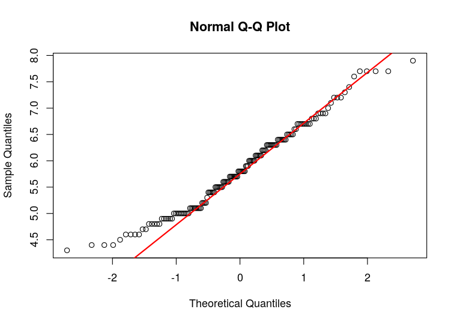

```r
qqnorm(iris$Sepal.Length)
qqline(
  iris$Sepal.Length,
  col = "red",
  lw = 2
)
```

# Ajuste de distribución

### extra

Se puede identificar una distribución mediante la **curtosis** y el **sesgo**.
R tiene paquetes que pueden facilitar esta tarea por ejemplo `fitdistrplus()`

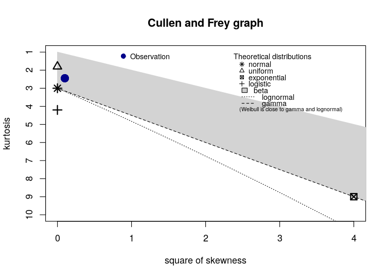

```
## summary statistics
## ------
## min:  4.3   max:  7.9
## median:  5.8
## mean:  5.843333
## estimated sd:  0.8280661
## estimated skewness:  0.314911
## estimated kurtosis:  2.447936
```

```r
descdist(iris$Sepal.Length)
```